# Inherited wit: An analysis of semantic similarities between works of political philosophers

In this project, we were given a massive dataset of quotes or excerpts from philosophers, from Aristotle to Wittgenstein.

It is quite likely that the teachings of one philosopher can influence another. To investigate connections between philosophers, this project aims to discover who influenced who. We will compare the key topics and phrases used by the various philosophers in the dataset and filter the data based on these findings. From there, if we can find philosophers that seem to have influenced other, then we can look into how their ideologies overlap.

The key tool that will be used to this end is semantic similarity. But what is semantic similarity and why should we care?

Semantic similarity is distinct from linguistic similarity in that it rather than simply looking at words used in a text, it considers the meanings of sentences when comparing their similarity.

For example, when comparing the quotes "whereof we do not yet know the issue." and "All this remains unknown.", an analysis of linguistic similarity would not detect any similarity at all because the two quotes have zero common words. However, an analysis of semantic similarity would show that these quotes are very similar, due to considering their meanings. This makes it a powerful and versatile tool for natural language processing, especially for a task such as this one.

Without further ado, let's dive into the analysis.

# Import modules and setting up data

It is heavily recommended to run this notebook on Google Colab to avoid possible errors with dependencies and unnecessary downloads. It is also convenient for navigation to hide or show sections as appropriate when traversing the notebook.

if running on colab, upload the following files to the workspace:

'philosophy_data.csv'

'enc_lenin.pickle'

'enc_marx.pickle'

Make sure to give enough time for philosophy_data.csv to fully download.

```python
# required for running in colab
!pip install transformers
!pip install sentence-transformers
```

```
     ━━━━━━━━━━━━━━━━━━━━━━━━━━━━━━━━━━━━━━━━ 6.3/6.3 MB 41.6 MB/s eta 0:00:00
     ━━━━━━━━━━━━━━━━━━━━━━━━━━━━━━━━━━━━━━━━ 7.6/7.6 MB 81.9 MB/s eta 0:00:00
     ━━━━━━━━━━━━━━━━━━━━━━━━━━━━━━━━━━━━━━ 190.3/190.3 KB 20.7 MB/s eta 0:00:00
     ━━━━━━━━━━━━━━━━━━━━━━━━━━━━━━━━━━━━━━━━ 86.0/86.0 KB 3.6 MB/s eta 0:00:00
  Preparing metadata (setup.py) ... done
     ━━━━━━━━━━━━━━━━━━━━━━━━━━━━━━━━━━━━━━━━ 1.3/1.3 MB 23.6 MB/s eta 0:00:00
```

```python
import seaborn as sns
import pandas as pd
import matplotlib.pyplot as plt
import itertools
from sentence_transformers import SentenceTransformer, util
import numpy as np
from wordcloud import WordCloud
import pickle
import nltk
nltk.download('stopwords')
from nltk.corpus import stopwords
```

```python
# downloading a pre-trained model used for semantic similarity
model = SentenceTransformer('stsb-roberta-large')
```

```python
# edit the path as necessary if running locally.
pdata = pd.read_csv('philosophy_data.csv')
```

```python
# # Function definitions
# # Same functions are contained in lib/relevant_functions.py
# # to import the functions from the folder if running locally
# # you could run the following 4 lines instead of defining the functions here
# import sys
# import os
# sys.path.append(os.getcwd()[:-3]+'lib')
# from relevant_functions import computeTF, computeIDF, computeTFIDF, wordclouder

def computeTF(wordDict, bagOfWords):
    tfDict = {}
    bagOfWordsCount = len(bagOfWords)
    for word, count in wordDict.items():
        tfDict[word] = count / float(bagOfWordsCount)
    return tfDict

def computeIDF(documents):
    import math
    N = len(documents)

    idfDict = dict.fromkeys(documents[0].keys(), 0)
    for document in documents:
        for word, val in document.items():
            if val > 0:
                idfDict[word] += 1

    for word, val in idfDict.items():
        idfDict[word] = math.log(N / float(val))
    return idfDict

def computeTFIDF(tfBagOfWords, idfs):
    tfidf = {}
    for word, val in tfBagOfWords.items():
        tfidf[word] = val * idfs[word]
    return tfidf

def wordclouder(authorname, weight):
    # create a dummy string
    wast = weight[authorname].nlargest(100)
    text2 = ''
    for i in range(len(wast)):
        text2 = text2 +  (wast.index[i] + ' ') * int(wast[i]*10000)

    # Creating word_cloud with text as argument in .generate() method
    word_cloud2 = WordCloud(collocations = False, background_color = 'white').generate(text2)

    # Display the generated Word Cloud
    plt.imshow(word_cloud2, interpolation='bilinear')
    plt.axis("off")
    plt.show()
```

# Initial analysis of semantic similarities between authors

To perform the analysis, all the quotes of each author are grouped together to form one big string per author. It is too computationally intensive to encode all the individual sentences separately.

```python
# compiling texts by each author, sorting alphabetically
quotes = (pdata.set_index('author')
               .groupby('author')['sentence_spacy']
               .transform(lambda x: ' '.join(x))
               .drop_duplicates()
               .sort_index())
quotes[:5]
```

```
author
Aristotle     When things have only a name in common and th...
Beauvoir     I hesitated a long time before writing a book ...
Berkeley      Good morrow, Hylas: I did not expect to find ...
Davis        When the influential scholar Ulrich. Phillips ...
Deleuze       Repetition and Difference Repetition is not g...
Name: sentence_spacy, dtype: object
```

After grouping the sentences and encoding them, we can analyze them and generate a heat map showing which authors are semantically similar to each other.

```python
# encode sentences to get their embeddings
# this step takes approx 2 mins
embeddings = [model.encode(i, convert_to_tensor=True) for i in quotes]
similarity_array = []
# compute similarity scores of two embeddings
for i in range(len(embeddings)):
  similarity_array.append([])
  for j in range(len(embeddings)):
    similarity_array[-1].append(util.pytorch_cos_sim(embeddings[i], embeddings[j]).item())

# convert result to dataframe
sim_df = pd.DataFrame(similarity_array,
                      index=quotes.index,
                      columns=quotes.index)

# to show the raw numbers, view sim_df
# sim_df
```

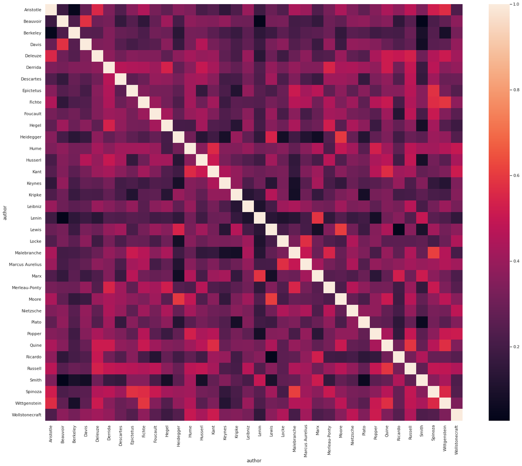

```python
sns.set(rc={'figure.figsize':(25,20.5)})
ax = sns.heatmap(sim_df,
                 linewidth=0)
ax.label_outer

plt.show()
```

This heat map shows data for every author in the dataset, hence the size of the image. The authors are arranged alphabetically. You may zoom in and pick one of your favorite authors, then see which other authors have semantically similar quotes to him/her/them - for example, Aristotle and Deleuze.

The benefit of having a heat map is that we can see the big picture before choosing potential authors to look into more deeply.

Next, we will highlight some of the most semantically similar authors below:

```python
# retrieving the top n similar authors

n = 10

top_similars = (sim_df.reset_index().melt(id_vars=["author"],
                                          var_name="author_2",
                                          value_name="similarity")
                                    .sort_values('similarity',ascending=False)
                                    .head(len(sim_df)+2*n).tail(2*n)
                                    .iloc[::2])
top_similars

# more sensitive to authors with similar mannerisms or writing habits
```

|  | author | author_2 | similarity |
| --- | --- | --- | --- |
| 789 | Spinoza | Malebranche | 0.609601 |
| 919 | Lewis | Moore | 0.607121 |
| 421 | Moore | Heidegger | 0.594800 |
| 322 | Wittgenstein | Fichte | 0.591761 |
| 1145 | Quine | Russell | 0.587859 |
| 846 | Lenin | Marx | 0.583242 |
| 1195 | Epictetus | Spinoza | 0.580960 |
| 39 | Davis | Beauvoir | 0.578808 |
| 742 | Marcus Aurelius | Locke | 0.573270 |
| 1078 | Wittgenstein | Quine | 0.571332 |

We've come up with some pairs of semantically similar authors, like Spinoza and Malebranche! They are both under the school of rationalism, while Lewis and Moore are both under the school of analytic, so this seems to make sense so far.

# Checking similar mannerisms or writing habits

The exercise above was our starting point, but we should consider that the analysis above also takes into account mannerisms or writing habits that authors tend to display.

Some philosophers uses sentences with similar meanings, but oftentimes the sentences say little about their beliefs and do not carry much real meaning.

A good example would be the one I brought up in the introduction. Consider again the quotes "whereof we do not yet know the issue." and "All this remains unknown." which are semantically similar, but do not carry much real information.

```python
s1 = "whereof we do not yet know the issue."
s2 = "All this remains unknown."
pdata[pdata['sentence_spacy'].transform(
    lambda x: any(x == q for q in [s1,s2]))]
```

|  | title | author | school | sentence_spacy | sentence_str | original_publication_date | corpus_edition_date | sentence_length | sentence_lowered | tokenized_txt | lemmatized_str |
| --- | --- | --- | --- | --- | --- | --- | --- | --- | --- | --- | --- |
| 108461 | Ethics | Spinoza | rationalism | whereof we do not yet know the issue. | whereof we do not yet know the issue. | 1677 | 2003 | 37 | whereof we do not yet know the issue. | ['whereof', 'we', 'do', 'not', 'yet', 'know', ... | whereof -PRON- do not yet know the issue . |
| 304729 | Essential Works Of Lenin | Lenin | communism | All this remains unknown. | All this remains unknown. | 1862 | 1966 | 25 | all this remains unknown. | ['all', 'this', 'remains', 'unknown'] | all this remain unknown . |

```python
# High similarity score
# (For reference, identical sentences have a similarity score of 1)
print('Similarity score between:\n"{0}"\n"{1}"\n\n{2}'.format(
    s1,
    s2,
    util.pytorch_cos_sim(model.encode(s1, convert_to_tensor=True),
                         model.encode(s2, convert_to_tensor=True)).item()))
```

```
Similarity score between:
"whereof we do not yet know the issue."
"All this remains unknown."

0.7437794208526611
```

The analysis above may still be useful to someone who wants to take into account the writing habits or tendencies that philosophers display, when considering whether they have a connection. These could reflect factors like personality.

Otherwise, if we want to circumvent this issue, we can consider filtering the dataset of quotes to only contain information about the key topics touched upon by our philosophers.

# Extracting key topics and phrases

We will use TF IDF to extract key topics and phrases of each philosopher.

```python
# remove stop words and punctuation. Takes around 24 seconds to run.
stopwords_ = stopwords.words('english') + ["'",'"','.',',','!','?',':','-pron-']
docs = (pdata.set_index('author')
               .groupby('author')['lemmatized_str']
               .transform(lambda x: ' '.join(x))
               .drop_duplicates()
               .sort_index())
docs = docs.transform(lambda x: ' '.join([i for i in x.lower().split() if i not in stopwords_ and len(i)>2]))
docs[:5]
```

```
author
Aristotle    thing name common definition correspond name d...
Beauvoir     hesitate long time write book woman subject ir...
Berkeley     good morrow hylas expect find abroad early ind...
Davis        influential scholar ulrich phillips declare sl...
Deleuze      repetition difference repetition generality re...
Name: lemmatized_str, dtype: object
```

```python
# reference: https://towardsdatascience.com/natural-language-processing-feature-engineering-using-tf-idf-e8b9d00e7e76
# full credit for the TFIDF functions goes to author of the article referenced

bags_of_words = [i.split(' ') for i in docs]
uniqueWords = set(itertools.chain.from_iterable(bags_of_words))

nwords = [dict.fromkeys(uniqueWords, 0) for d in docs]

for i in range(len(nwords)):
  for word in bags_of_words[i]:
    nwords[i][word] += 1

tfs = []
# idfs = []
for i in range(len(docs)):
  tfs.append(computeTF(nwords[i],bags_of_words[i]))
idfs = computeIDF(nwords)

tfidfs = [computeTFIDF(tfi, idfs) for tfi in tfs]
```

The key words for each philosopher are as shown below.

For some philospohers, their key words obviously show what kinds of topics they are focused on - for example, Beauvoir talks about feminism.

```python
df = pd.DataFrame(tfidfs).set_index(docs.index)
weights = df.T
keywords = pd.DataFrame()
for i in weights:
  keywords[i] = weights[i].nlargest(10).index
keywords.T
```

|  | 0 | 1 | 2 | 3 | 4 | 5 | 6 | 7 | 8 | 9 |
| --- | --- | --- | --- | --- | --- | --- | --- | --- | --- | --- |
| Aristotle | semen | nutriment | moisture | incontinent | oviparous | genus | quadruped | female | male | moist |
| Beauvoir | woman | girl | feminine | male | mme | husband | sexual | montherlant | masculine | colette |
| Berkeley | philonous | hylas | unperceiving | doth | unthinking | repugnancy | hath | sensible | colour | idea |
| Davis | lynching | racism | suffrage | douglass | woman | racist | rape | stanton | housework | wells |
| Deleuze | oedipus | oedipal | signifier | psychoanalysis | investment | socius | capitalism | extensity | schizophrenic | differenciation |
| Derrida | levinas | artaud | foucault | theater | husserl | freud | rousset | phenomenology | alterity | bataille |
| Descartes | artery | cognosco | judgement | cavity | supremely | suchlike | venous | scio | arterial | nonetheless |
| Epictetus | elated | obulus | chrysippus | lettuce | gladiator | procrastination | diviner | revile | hurt | portend |
| Fichte | posit | concept | cognition | determinacy | consciousness | duty | morality | sufficiency | acting | insofar |
| Foucault | madness | unreason | confinement | pinel | eighteenth | medical | bic | classical | century | bichat |
| Hegel | determinateness | positedness | sublate | posit | externality | immediacy | concept | quantum | negativity | universality |
| Heidegger | dasein | sein | innerworldly | temporality | ontological | existential | disclosedness | factical | ownmost | ontologically |
| Hume | betwixt | encrease | coue | passion | vivacity | phaenomenon | humility | connexion | sentiment | possest |
| Husserl | epoche | givenness | pregiven | transcendental | psychic | psychology | ego | ontic | horizon | prescientific |
| Kant | cognition | concept | purposiveness | judgement | cognize | empirical | transcendental | alaska | priori | intuition |
| Keynes | investment | output | income | marginal | liquidity | wage | entrepreneur | asset | consumption | equipment |
| Kripke | nozick | frege | counterfactual | hesperus | russell | quine | nixon | referent | barn | kaplan |
| Leibniz | bayle | mysteries | augustine | goodness | chrysippus | theologian | equipoise | schoolmen | grace | thomists |
| Lenin | kautsky | capitalism | capitalist | dyelo | rabocheye | imperialism | engels | proletariat | marx | bourgeois |
| Lewis | counterfactual | continuant | iff | intension | causal | holmes | modal | conditional | credence | assertability |
| Locke | hath | idea | legislative | whereof | andc | whilst | concernment | wherein | commonwealth | connexion |
| Malebranche | vortex | enor | fiber | lens | lhe | color | toward | concupiscence | prevenient | elucidations |
| Marcus Aurelius | thou | thee | thy | doth | thyself | unto | hast | dost | doest | hath |
| Marx | labour | capitalist | commodity | labourer | capital | surplus | factory | andc | machinery | cotton |
| Merleau-Ponty | reﬂection | perception | intellectualism | tactile | consciousness | perceptual | husserl | cogito | visual | sexuality |
| Moore | inkstand | generalisation | percipi | bradley | relational | perception | unicorn | blue | perceptibly | patch |
| Nietzsche | zarathustra | thou | thee | hath | thy | verily | doth | spake | yea | unto |
| Plato | socrates | clinias | protagoras | expertise | zeus | glaucon | dion | theaetetus | cebes | gorgias |
| Popper | falsifiability | falsifiable | statement | heisenberg | testable | probability | sequence | frequency | bernoulli | testability |
| Quine | objct | ust | carnap | synonymy | analyticity | sentence | quantification | arc | ect | modal |
| Ricardo | commodity | tax | corn | labour | rent | price | landlord | capital | labourer | percent |
| Russell | mnemic | cassio | introspection | desdemona | datum | psychology | semon | othello | sensation | image |
| Smith | revenue | labour | tax | shilling | britain | exportation | trade | silver | commodity | price |
| Spinoza | emotion | coroll | def | prop | wherefore | andc | e.d. | endeavour | emotions | pleasurably |
| Wittgenstein | moore | shew | someone | queer | chess | ostensive | frege | slab | sentence | connexion |
| Wollstonecraft | woman | sex | rousseau | female | whilst | husband | sensibility | affection | girl | superiour |

Next, we will filter our dataset of quotes to only contain quotes that contain key words from each of their respective philosophers, then use this to run our analysis again.

This way, we keep only the quotes that are most relevant to the key topics the discuss. Taking Beauvoir as an example again, this would mean we only keep quotes where Beauvoir mentions words like "woman" and "girl".

```python
# Takes approx 2 minutes to filter.
pdata_f = pd.DataFrame(columns=pdata.columns)
for i in keywords:
  pdata_f = pd.concat([pdata_f,
                       pdata[pdata['author']==i][pdata['lemmatized_str']
                                                 .transform(lambda x: any(word in x for word in keywords[i]))
                                                 ]])
pdata_f
```

|  | title | author | school | sentence_spacy | sentence_str | original_publication_date | corpus_edition_date | sentence_length | sentence_lowered | tokenized_txt | lemmatized_str |
| --- | --- | --- | --- | --- | --- | --- | --- | --- | --- | --- | --- |
| 38391 | Aristotle - Complete Works | Aristotle | aristotle | The differentiae of genera which are differe a... | The differentiae of genera which are differe a... | -320 | 1991 | 115 | the differentiae of genera which are differe a... | ['the', 'differentiae', 'of', 'genera', 'which... | the differentiae of genus which be differe an... |
| 38393 | Aristotle - Complete Works | Aristotle | aristotle | However, there is nothing to prevent genera su... | However, there is nothing to prevent genera su... | -320 | 1991 | 107 | however, there is nothing to prevent genera su... | ['however', 'there', 'is', 'nothing', 'to', 'p... | however , there be nothing to prevent genus s... |
| 38394 | Aristotle - Complete Works | Aristotle | aristotle | For the higher are predicated of the genera be... | For the higher are predicated of the genera be... | -320 | 1991 | 146 | for the higher are predicated of the genera be... | ['for', 'the', 'higher', 'are', 'predicated', ... | for the high be predicate of the genus below ... |
| 38402 | Aristotle - Complete Works | Aristotle | aristotle | The species in which the things primarily call... | The species in which the things primarily call... | -320 | 1991 | 138 | the species in which the things primarily call... | ['the', 'species', 'in', 'which', 'the', 'thin... | the specie in which the thing primarily call ... |
| 38403 | Aristotle - Complete Works | Aristotle | aristotle | For example, the individual man belongs in a s... | For example, the individual man belongs in a s... | -320 | 1991 | 158 | for example, the individual man belongs in a s... | ['for', 'example', 'the', 'individual', 'man',... | for example , the individual man belong in a ... |
| ... | ... | ... | ... | ... | ... | ... | ... | ... | ... | ... | ... |
| 344725 | Vindication Of The Rights Of Woman | Wollstonecraft | feminism | Asserting the rights which women in common wit... | Asserting the rights which women in common wit... | 1792 | 2001 | 212 | asserting the rights which women in common wit... | ['asserting', 'the', 'rights', 'which', 'women... | assert the right which woman in common with m... |
| 344727 | Vindication Of The Rights Of Woman | Wollstonecraft | feminism | Let woman share the rights, and she will emula... | Let woman share the rights, and she will emula... | 1792 | 2001 | 185 | let woman share the rights, and she will emula... | ['let', 'woman', 'share', 'the', 'rights', 'an... | let woman share the right , and -PRON- will e... |
| 344728 | Vindication Of The Rights Of Woman | Wollstonecraft | feminism | If the latter, it will be expedient to open a ... | If the latter, it will be expedient to open a ... | 1792 | 2001 | 470 | if the latter, it will be expedient to open a ... | ['if', 'the', 'latter', 'it', 'will', 'be', 'e... | if the latter , -PRON- will be expedient to o... |
| 344729 | Vindication Of The Rights Of Woman | Wollstonecraft | feminism | Allowing this position, women have not any inh... | Allowing this position, women have not any inh... | 1792 | 2001 | 150 | allowing this position, women have not any inh... | ['allowing', 'this', 'position', 'women', 'hav... | allow this position , woman have not any inhe... |
| 344731 | Vindication Of The Rights Of Woman | Wollstonecraft | feminism | and mark not more severely what women do amiss... | and mark not more severely what women do amiss... | 1792 | 2001 | 314 | and mark not more severely what women do amiss... | ['and', 'mark', 'not', 'more', 'severely', 'wh... | and mark not more severely what woman do amis... |

72988 rows × 11 columns

# Semantic similarity analysis revisited

Next, let's revisit the semantic similarity analysis.

We'll make a new heat map.

```python
quotes = (pdata_f.set_index('author')
               .groupby('author')['sentence_spacy']
               .transform(lambda x: ' '.join(x))
               .drop_duplicates()
               .sort_index())

# encode sentences to get their embeddings
# again, this step may take some time
embeddings = [model.encode(i, convert_to_tensor=True) for i in quotes]
similarity_array = []
# compute similarity scores of two embeddings
for i in range(len(embeddings)):
  similarity_array.append([])
  for j in range(len(embeddings)):
    similarity_array[-1].append(util.pytorch_cos_sim(embeddings[i], embeddings[j]).item())
```

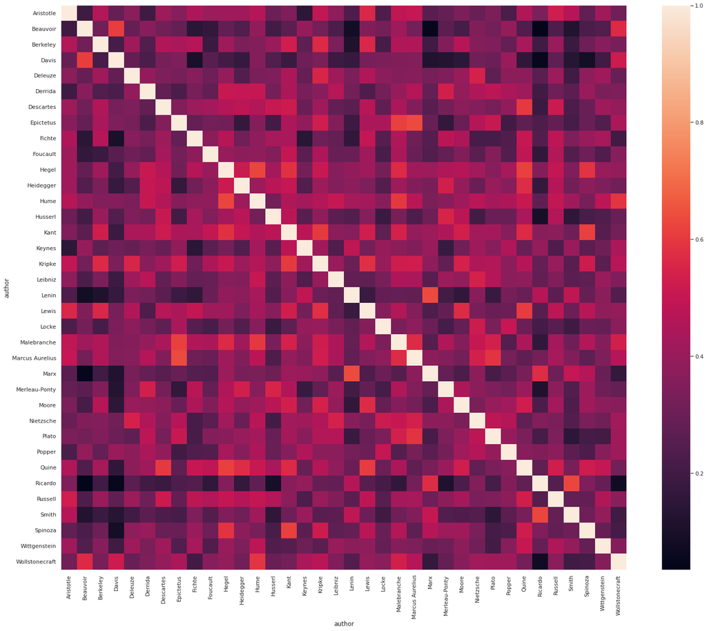

```python
sim_df_2 = pd.DataFrame(similarity_array,
                      index=quotes.index,
                      columns=quotes.index)

sns.set(rc={'figure.figsize':(25,20.5)})
ax = sns.heatmap(sim_df_2,
                 linewidth=0)
ax.label_outer

plt.show()
```

This heat map seems a bit brighter than last time!

```python
# retrieving the top n similar authors

n = 10

top_similars = (sim_df_2.reset_index().melt(id_vars=["author"],
                                          var_name="author_2",
                                          value_name="similarity score")
                                    .sort_values('similarity score',ascending=False)
                                    .head(len(sim_df)+2*n).tail(2*n)
                                    .iloc[::2])
top_similars
```

|  | author | author_2 | similarity score |
| --- | --- | --- | --- |
| 846 | Lenin | Marx | 0.637223 |
| 799 | Epictetus | Marcus Aurelius | 0.636692 |
| 1182 | Ricardo | Smith | 0.630274 |
| 372 | Hume | Hegel | 0.623618 |
| 389 | Quine | Hegel | 0.618320 |
| 763 | Epictetus | Malebranche | 0.614356 |
| 537 | Spinoza | Kant | 0.611938 |
| 39 | Davis | Beauvoir | 0.609825 |
| 1063 | Lewis | Quine | 0.606407 |
| 245 | Quine | Descartes | 0.603589 |

This time, at the top of the list we have Lenin and Marx! These two are well-known by historians for their role in the history of communism.

Next, let's compare the key words of Lenin and Marx with a more visual approach.

# Comparisons of key words

The word clouds below, upper one being Marx's and lower one being Lenin's, are a visual representation of the key terms used by the two authors according to our TF IDF analysis.

We can see that they both talk about capitalism and members of social classes, like labourers and bourgeois.

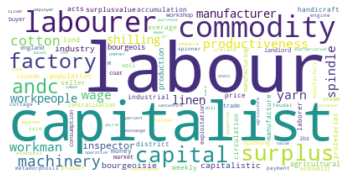

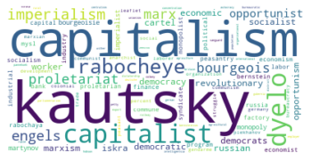

```python
# Let's look at the word clouds for Marx and Lenin respectively.
%matplotlib inline
wordclouder('Marx', weights)
wordclouder('Lenin', weights)
```

Just for fun, we also compare Ricardo and Smith's word clouds here. It is apparent that both of them write about economic topics.

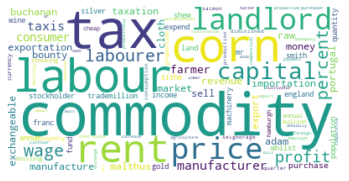

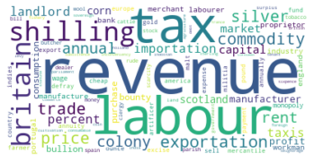

```python
# Let's look at the word clouds for Ricardo and Smith respectively.
%matplotlib inline
wordclouder('Ricardo', weights)
wordclouder('Smith', weights)
```

Lastly, I personally found Aristotle's word cloud to be interesting, although this is a little bit off-topic.

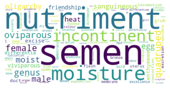

```python
# Just for fun, an additional word cloud for Aristotle
wordclouder('Aristotle', weights)
```

# Marx and Lenin: A closer look

Having noted their high semantic similarity scores and their similar word clouds, let's dig deep into the quotes by Marx and Lenin!

This time, we are analyzing individual quotes by Marx and Lenin, then comparing them to find the overlap in their ideologies. The analysis is made possible through the filtering using TF IDF that removed the irrelevant quotes.

```python
pdata_marxlenin = pdata[(pdata['author']=='Lenin') | (pdata['author']=='Marx')][pdata['lemmatized_str'].transform(
    lambda x:
    any(word in x for word in keywords['Lenin'][:5]) and
    any(word in x for word in keywords['Marx'][:5]))]

lenin = pdata_marxlenin[pdata_marxlenin['author']=="Lenin"]['sentence_spacy']
marx = pdata_marxlenin[pdata_marxlenin['author']=="Marx"]['sentence_spacy']

# Takes approx 15 minutes to encode. We can download the pickled files instead
# to skip the long encoding process. These files are found in the output folder.
# It's more computationally intensive because we are encoding many individual
# sentences rather than a few large chunks of text.

# enc_ln = [model.encode(i, convert_to_tensor=True) for i in lenin]
# enc_mx = [model.encode(i, convert_to_tensor=True) for i in marx]

# # saving the data
# with open("enc_marx.pickle", "wb") as fp:
#   pickle.dump(enc_mx, fp)
# with open("enc_lenin.pickle", "wb") as fp:
#   pickle.dump(enc_ln, fp)

with open('enc_marx.pickle', 'rb') as handle:
  enc_mx = pickle.load(handle)
with open('enc_lenin.pickle', 'rb') as handle:
  enc_ln = pickle.load(handle)

# if running locally use these file paths
# os.getcwd()[:-3]+'output\\enc_marx.pickle'
# os.getcwd()[:-3]+'output\\enc_lenin.pickle'
```

```python
# Making another similarity array, sa2
sa2 = []
mx = 0
for i in range(len(enc_mx)):
  sa2.append([])
  for j in range(len(enc_ln)):
    scr = util.pytorch_cos_sim(enc_mx[i], enc_ln[j]).item()
    sa2[-1].append(scr)
    if scr > mx:
      mx = scr
      dims = [i,j]
```

```python
# Retrieve the top N most similar pairs of quotes, without replacement

N = 3
sa2 = np.array([np.array(xi) for xi in sa2])

# Convert it into a 1D array
a_1d = sa2.flatten()

# Find the indices in the 1D array
idx_1d = a_1d.argsort()

# convert the idx_1d back into indices arrays for each dimension
x_idx, y_idx = np.unravel_index(idx_1d, sa2.shape)

x_idx = np.flip(x_idx)
y_idx = np.flip(y_idx)

x_blacklist = []
y_blacklist = []
new_x = []
new_y = []

for i in range(len(x_idx)):
  if x_idx[i] not in x_blacklist and y_idx[i] not in y_blacklist:
    new_x.append(x_idx[i])
    new_y.append(y_idx[i])
    x_blacklist.append(x_idx[i])
    y_blacklist.append(y_idx[i])
  if len(new_y) > N-1:
    break

print("Top {} most similar pairs of quotes, without replacement".format(N))
print()

for x, y, in zip(new_x, new_y):
    print("Marx:",marx.iloc[x])
    print("Lenin:",lenin.iloc[y])
    print()
```

```
Top 3 most similar pairs of quotes, without replacement

Marx: On the one hand, the process of production incessantly converts material wealth into capital, into means of creating more wealth and means of enjoyment for the capitalist.
Lenin: In doing so they transform inactive money capital into active capital, that is, into capital producing a profit; they collect all kinds of money revenues and place them at the disposal of the capitalist class.

Marx: The more the capitalist has accumulated, the more is he able to accumulate.
Lenin: In this way they gradually acquire the ability to accumulate a certain amount of wealth and to transform themselves even into future capitalists.

Marx: The same cause which may increase the revenue of the country (i.e., as Ricardo explains in the same passage, the revenues of landlords and capitalists, whose wealth, from the economic point of view, forms the Wealth of the Nation), may at the same time render the population redundant and deter…
Lenin: As long as capitalism remains what it is, surplus capital will never be utilized for the purpose of raising the standard of living of the masses in a given country, for this would mean a decline in profits for the capitalists; it will be used for the purpose of increasing those profits by exp…
```

We have been given important quotes by Marx and Lenin that demonstrate their ideological overlap, and potentially the influence that Marx had on Lenin's thinking.

Let's focus on the pair of quotes that got the highest semantic similarity score...

Marx: *On the one hand, the process of production incessantly converts material wealth into capital, into means of creating more wealth and means of enjoyment for the capitalist.*

Lenin: *In doing so they transform inactive money capital into active capital, that is, into capital producing a profit; they collect all kinds of money revenues and place them at the disposal of the capitalist class.*

Summarized, these quotes essentially show us that Marx and Lenin both comment on how the system of capitalism allows the rich to use their wealth to become richer.

# Concluding remarks

We have uncovered from the dataset a pair of philosophers that share a view on the system of capitalism, using semantic similarity, TF IDF, and data visualizations.

This analysis could also be performed on other pairs of philosophers, not just Marx and Lenin. The heat map visualizations suggest that there are many more places to dig deeper.

Marx is indeed quite an influential and controversial figure. For potential future analysis we can even consider other authors who have writings that are semantically similar to the writings of Marx. I will leave you with the heat map below, which suggests other philosophers whose relationship with Marx could be further investigated.

```
author
Lenin        0.637223
Ricardo      0.572175
Smith        0.499255
Spinoza      0.466748
Kant         0.409659
Hegel        0.409217
Keynes       0.400761
Kripke       0.381668
Nietzsche    0.375347
Name: Marx, dtype: float64
```

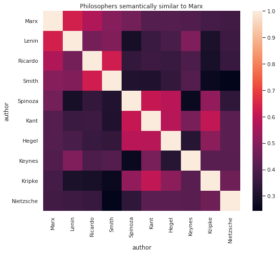

```python
sns.set(rc={'figure.figsize':(9,7.5)})

marx = pd.DataFrame(similarity_array,
                    index=quotes.index,
                    columns=quotes.index).nlargest(10,['Marx'])

marx = marx[marx.index]
ax = sns.heatmap(marx,
                 linewidth=0)
ax.label_outer

print(marx.iloc[1:,0])

plt.title("Philosophers semantically similar to Marx")
plt.show()
```

```python
%%shell
jupyter nbconvert --to html /content/proj1_5243.ipynb
```

```
[NbConvertApp] Converting notebook /content/proj1_5243.ipynb to html
[NbConvertApp] Writing 1284494 bytes to /content/proj1_5243.html
```